# Devoir Econométrie L3 S2 Hétéroscédasticité

# Question 1

Après avoir enlevé la valeur manquante, on crée les dummies sex avec comme valeur de référence les hommes, agedummy avec comme valeur de référence les hommes de moins de 30 ans, towndummy avec les petites et moyennes villes ($<3$) comme référence et enfin, la dummy size avec comme référence les familles inférieures ou égales à 5 personnes :

```
##
## FALSE  TRUE
## 23971     1
```

```
## 'data.frame':    23971 obs. of  7 variables:
##  $ X     : int  1 2 3 4 5 6 7 8 9 10 ...
##  $ wfood : num  0.468 0.313 0.376 0.44 0.404 ...
##  $ totexp: int  1290941 1277978 845852 527698 1103220 1768128 1107529 737959 1019848 2149883 ...
##  $ age   : int  43 40 28 60 37 35 40 68 43 51 ...
##  $ size  : int  5 3 3 1 5 4 4 2 9 7 ...
##  $ town  : int  2 2 2 2 2 2 2 2 2 2 ...
##  $ sex   : Factor w/ 2 levels "man","woman": 1 1 1 2 1 1 1 2 1 1 ...
##  - attr(*, "na.action")= 'omit' Named int 14015
##   ..- attr(*, "names")= chr "14015"
```

```
##
##     1     2
## 20624  3347
```

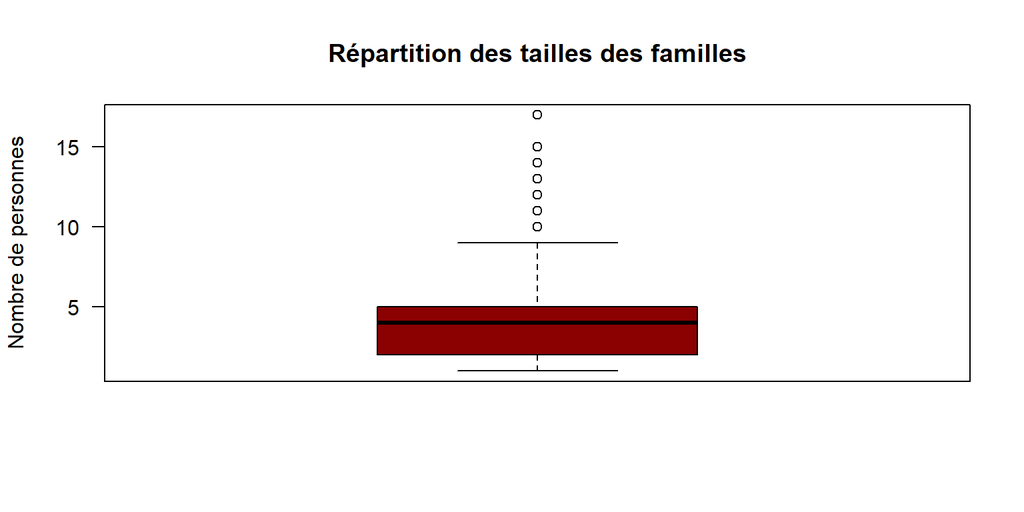

```
##
##         0         1
## 0.8569104 0.1430896
```

Ici nous cherchons à comparer la part des revenus allouée au salaire pour les personnes de moins de 30 ans, ce qui veut dire, les personnes débutants dans la vie active que l’on compare aux personnes un peu plus avancées et dans des situations souvent plus confortables. Nous décidons également de comparer les petites et moyennes villes aux plus grandes. En effet, on sait que les salaires sont plus élevés dans les grandes villes mais les prix sont également plus élevés. Nous voulons donc voir si la part du revenu allouée à l’alimentation entre moyennes et grandes villes va être significativement différent de 0 ou pas. Autrement dit, est-ce que l’augmentation des salaires est plus élevée que l’augmentation des prix des denrées alimentaires.

De plus, nous avons décidé de comparer les familles qui compte jusqu’à 3 enfants (potentiellement 2 parents et 3 enfants donc on aurait une famille d’au maximum 5 personnes) et les familles de plus de 3 enfants parce que d’après nos a priori, on pourrait se dire que plus l’on a d’enfant et plus l’on possède une famille nombreuse, plus la part de notre revenu allouée à la consommation sera importante. De plus, d’après notre diagramme en boîte, il semblerait que seulement 85% des familles sont composées de 5 personnes ou moins. Il y aurait donc 15% des familles composées de plus de 5 personnes, ce qui représente une proportion non négligeable.

Comme 1er modèle, nous testons le modèle simple, contenant toutes les variables sans les modifier :

```
##
## Call:
## lm(formula = wfood ~ totexp + age + size + town + sex)
##
## Residuals:
##      Min       1Q   Median       3Q      Max
## -0.60931 -0.08809 -0.00964  0.07991  1.17272
##
## Coefficients:
##               Estimate Std. Error t value Pr(>|t|)
## (Intercept)  3.672e-01  5.164e-03  71.122  < 2e-16 ***
## totexp      -1.385e-07  1.529e-09 -90.602  < 2e-16 ***
## age          2.169e-03  6.284e-05  34.521  < 2e-16 ***
## size         2.191e-02  5.663e-04  38.694  < 2e-16 ***
## town        -1.804e-02  7.363e-04 -24.500  < 2e-16 ***
## sex         -8.329e-03  2.688e-03  -3.098  0.00195 **
## ---
## Signif. codes:  0 '***' 0.001 '**' 0.01 '*' 0.05 '.' 0.1 ' ' 1
##
## Residual standard error: 0.1337 on 23965 degrees of freedom
## Multiple R-squared:  0.3489, Adjusted R-squared:  0.3487
## F-statistic:  2568 on 5 and 23965 DF,  p-value: < 2.2e-16
```

```
##
## =============================================================
##                                      Dependent variable:
##                                  ----------------------------
##                                             wfood
##                                       (1)            (2)
## -------------------------------------------------------------
## totexp                            -0.00000***    -0.00000***
##                                     (0.000)        (0.000)
##
## age                                 0.002***
##                                     (0.0001)
##
## agecarre                                         0.00002***
##                                                   (0.00000)
##
## size                                0.022***      0.023***
##                                     (0.001)        (0.001)
##
## town                               -0.018***      -0.018***
##                                     (0.001)        (0.001)
##
## sex                                -0.008***      -0.009***
##                                     (0.003)        (0.003)
##
## Constant                            0.367***      0.416***
##                                     (0.005)        (0.004)
##
## -------------------------------------------------------------
## Observations                         23,971        23,971
## R2                                   0.349          0.348
## Adjusted R2                          0.349          0.348
## Residual Std. Error (df = 23965)     0.134          0.134
## F Statistic (df = 5; 23965)       2,568.094***  2,559.341***
## =============================================================
## Note:                             *p<0.1; **p<0.05; ***p<0.01
```

```
## Analysis of Variance Table
##
## Model 1: wfood ~ totexp + age + size + town + sex
## Model 2: wfood ~ totexp + agecarre + size + town + sex
##   Res.Df    RSS Df Sum of Sq F Pr(>F)
## 1  23965 428.25
## 2  23965 428.76  0  -0.50985
```

Tous les coefficients sont significatifs. La variable age a gagné en précision, l’écart-type est passé à 0, mais elle a maintenant un effet plus faible sur wfood. Ici, on remarque que les 2 modèles sont quasiment similaires donc on a pas d’intérêt à mettre la variable age au carré.

Pour ce 3ème modèle, on décide de mettre les variables age et town en dummies comme expliqué ci-dessus :

```
##
## =============================================================
##                                      Dependent variable:
##                                  ----------------------------
##                                             wfood
##                                       (1)            (2)
## -------------------------------------------------------------
## totexp                            -0.00000***    -0.00000***
##                                     (0.000)        (0.000)
##
## age                                 0.002***
##                                     (0.0001)
##
## agedummy                                          0.069***
##                                                    (0.003)
##
## size                                0.022***      0.016***
##                                     (0.001)        (0.001)
##
## town                               -0.018***
##                                     (0.001)
##
## towndummy                                         -0.042***
##                                                    (0.002)
##
## sex                                -0.008***       -0.0005
##                                     (0.003)        (0.003)
##
## Constant                            0.367***      0.405***
##                                     (0.005)        (0.004)
##
## -------------------------------------------------------------
## Observations                         23,971        23,971
## R2                                   0.349          0.325
## Adjusted R2                          0.349          0.325
## Residual Std. Error (df = 23965)     0.134          0.136
## F Statistic (df = 5; 23965)       2,568.094***  2,307.045***
## =============================================================
## Note:                             *p<0.1; **p<0.05; ***p<0.01
```

Il semblerait que le modèle simple soit plus précis que le modèle avec les variables dummies. En effet, le $R^2$ du modèle est un peu plus élevé. De plus, on observe que les écarts-types des 2 variables town et age sont plus faibles quand elles ne sont pas mis en dummies. Cependant, il semblerait que l’ajout des dummies age et town a enlevé la significativité de la variable sex, il faudrait donc enlever cette variable dans le modèle 3.

# Question 2

On regarde la matrice des covariances :

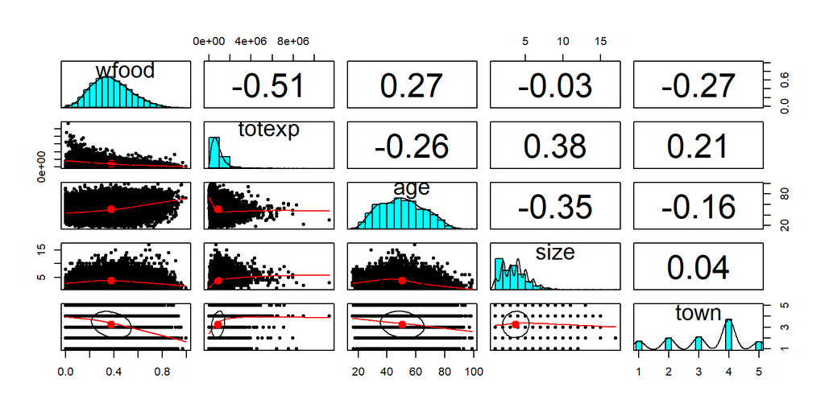

On remarque qu’il semblerait y avoir des relations entre la variable totexp et les variables age et size. Nous allons essayer de les mettre en relation pour voir si notre modèle s’améliore ou pas :

```
##
## ================================================
##                         Dependent variable:
##                     ----------------------------
##                                wfood
## ------------------------------------------------
## totexp                      -0.00000***
##                               (0.000)
##
## age                           0.003***
##                               (0.0001)
##
## size                          0.017***
##                               (0.001)
##
## town                         -0.018***
##                               (0.001)
##
## sex                          -0.015***
##                               (0.003)
##
## totexp:age                   -0.000***
##                               (0.000)
##
## totexp:size                   0.000***
##                               (0.000)
##
## Constant                      0.344***
##                               (0.008)
##
## ------------------------------------------------
## Observations                   23,971
## R2                             0.357
## Adjusted R2                    0.356
## Residual Std. Error      0.133 (df = 23963)
## F Statistic         1,896.857*** (df = 7; 23963)
## ================================================
## Note:                *p<0.1; **p<0.05; ***p<0.01
```

Par rapport au modèle 1, nous avons amélioré le $R^2$ avec ce modèle 4. On rejette toujours l’hypothèse H0 des coefficients nuls et de plus, on remarque que nos coefficients sont toujours tous significatifs. Il semblerait donc que l’on peut mettre en relation les dépenses totales et l’âge et la taille du ménage.  
On essaye maintenant un modèle en mettant en interaction les variables age avec les variables totexp et size :

```
##
## ================================================
##                         Dependent variable:
##                     ----------------------------
##                                wfood
## ------------------------------------------------
## totexp                      -0.00000***
##                               (0.000)
##
## age                           0.004***
##                               (0.0001)
##
## size                          0.039***
##                               (0.002)
##
## town                         -0.018***
##                               (0.001)
##
## sex                          -0.013***
##                               (0.003)
##
## totexp:age                   -0.000***
##                               (0.000)
##
## age:size                     -0.0003***
##                              (0.00004)
##
## Constant                      0.266***
##                               (0.009)
##
## ------------------------------------------------
## Observations                   23,971
## R2                             0.356
## Adjusted R2                    0.355
## Residual Std. Error      0.133 (df = 23963)
## F Statistic         1,888.348*** (df = 7; 23963)
## ================================================
## Note:                *p<0.1; **p<0.05; ***p<0.01
```

Les coefficients sont tous significatifs et le $R^2$ est proche de celui du modèle 4. On rejette toujours l’hypothèse H0 des coefficients nuls. On observe également que les variances des 2 modèles ne sont pas significativement différentes :

```
## Analysis of Variance Table
##
## Model 1: wfood ~ totexp * age + totexp * size + town + sex
## Model 2: wfood ~ totexp * age + age * size + town + sex
##   Res.Df    RSS Df Sum of Sq F Pr(>F)
## 1  23963 423.21
## 2  23963 423.89  0  -0.67793
```

Enfin, les critères AIC et BIC nous indiquent que le modèle 4 semblerait meilleur que le modèle 5 :

```
## [1] -28719.67 -28681.30
```

```
## [1] -28646.91 -28608.54
```

# Question 3

On décide de créer le modèle simple mais en prenant cette fois-ci les logarithmes des variables totexp et age :

```
##
## ================================================
##                         Dependent variable:
##                     ----------------------------
##                                wfood
## ------------------------------------------------
## logtotexp                    -0.146***
##                               (0.001)
##
## logage                        0.065***
##                               (0.003)
##
## size                          0.026***
##                               (0.001)
##
## town                         -0.013***
##                               (0.001)
##
## sex                          -0.031***
##                               (0.003)
##
## Constant                      2.031***
##                               (0.023)
##
## ------------------------------------------------
## Observations                   23,971
## R2                             0.392
## Adjusted R2                    0.392
## Residual Std. Error      0.129 (df = 23965)
## F Statistic         3,095.867*** (df = 5; 23965)
## ================================================
## Note:                *p<0.1; **p<0.05; ***p<0.01
```

On observe une nette augmentation du $R^2$ qui passe à 0.392. De plus, les coefficients sont toujours tous significatifs et on remarque qu’il est plus facile de lire les estimations des coefficients comme nous n’avons plus de variable très très petite. La statiistique de Fisher est toujours très élevés donc on rejette encore l’hypothèse H0 qui dit que les coefficients sont nuls.

Le modèle 7 est le meilleur modèle que nous avons trouvé avec des variables en interaction et les variables age et totexp en logarithme :

```
##
## ================================================
##                         Dependent variable:
##                     ----------------------------
##                                wfood
## ------------------------------------------------
## logtotexp                    -0.116***
##                               (0.003)
##
## logage                        0.076***
##                               (0.003)
##
## size                          0.170***
##                               (0.010)
##
## town                         -0.012***
##                               (0.001)
##
## sex                          -0.260***
##                               (0.043)
##
## logtotexp:size               -0.011***
##                               (0.001)
##
## logtotexp:sex                 0.018***
##                               (0.003)
##
## Constant                      1.582***
##                               (0.045)
##
## ------------------------------------------------
## Observations                   23,971
## R2                             0.402
## Adjusted R2                    0.401
## Residual Std. Error      0.128 (df = 23963)
## F Statistic         2,297.186*** (df = 7; 23963)
## ================================================
## Note:                *p<0.1; **p<0.05; ***p<0.01
```

On remarque que tous les coefficients sont différents de 0 et significatifs. De plus, le $R^2$ a augmenté à 0.402.

```
## Analysis of Variance Table
##
## Model 1: wfood ~ totexp * age + totexp * size + town + sex
## Model 2: wfood ~ logtotexp + logage + logtotexp * size + town + logtotexp *
##     sex
##   Res.Df    RSS Df Sum of Sq F Pr(>F)
## 1  23963 423.21
## 2  23963 393.59  0    29.617
```

```
## [1] -28719.67 -30458.80
```

```
## [1] -28646.91 -30386.03
```

Avec le test ANOVA, on observe que les variances ne sont pas significativement différentes. Enfin, les critères AIC et BIC nous indiquent que le modèle 7 serait meilleur.

```
##
## =============================================================
##                                      Dependent variable:
##                                  ----------------------------
##                                             wfood
##                                       (1)            (2)
## -------------------------------------------------------------
## totexp                            -0.00000***
##                                     (0.000)
##
## age                                 0.003***
##                                     (0.0001)
##
## logtotexp                                         -0.116***
##                                                    (0.003)
##
## logage                                            0.076***
##                                                    (0.003)
##
## size                                0.017***      0.170***
##                                     (0.001)        (0.010)
##
## town                               -0.018***      -0.012***
##                                     (0.001)        (0.001)
##
## sex                                -0.015***      -0.260***
##                                     (0.003)        (0.043)
##
## totexp:age                         -0.000***
##                                     (0.000)
##
## totexp:size                         0.000***
##                                     (0.000)
##
## logtotexp:size                                    -0.011***
##                                                    (0.001)
##
## logtotexp:sex                                     0.018***
##                                                    (0.003)
##
## Constant                            0.344***      1.582***
##                                     (0.008)        (0.045)
##
## -------------------------------------------------------------
## Observations                         23,971        23,971
## R2                                   0.357          0.402
## Adjusted R2                          0.356          0.401
## Residual Std. Error (df = 23963)     0.133          0.128
## F Statistic (df = 7; 23963)       1,896.857***  2,297.186***
## =============================================================
## Note:                             *p<0.1; **p<0.05; ***p<0.01
```

L’erreur des résidus standardisés est également plus faible, le modèle 7 serait donc plus précis.

CORRE FETEIRA DHORBAIT

2020-04-01